# deconvR : Simulation and Deconvolution of Cellular Signatures

Veronika Ebenal

2021-09-25

#### Package

deconvR 0.99.0

# 1 Introduction

`deconvR` is a collection of functions surrounding the deconvolution of bulk sample(s) with the use of a reference atlas of signature profiles and a user-selected model. The user may provide their own reference atlas, use the reference atlas provided in `inst`, or create/extend a new reference atlas using `findSignatures`. The user may provide their own bulk samples table, or use `simulateCellMix` to generate a simulated table of a desired number of samples, with either user-specified or random origin proportions. Alternatively, in the case of methylation profiles, `BSMeth2Probe` may be used to map WGBS methylation data (as a dataframe or **GRanges** object) to probe IDs, and the results of this mapping may be used as the bulk samples in the deconvolution. Finally, along with a reference atlas and table of bulk samples, `deconvolute` allows the user to specify their desired deconvolution model (non-negative least squares regression, support vector regression, quadratic programming, or robust linear regression), and returns a dataframe which contains predicted cell-type proportions of bulk methylation profiles, as well as partial R-squared values for each sample. The user may provide a vector with which partial R-squared of the results will be calculated. Otherwise, partial R-squared values will be calculated using the row means of the reference atlas.

# 2 Installation

You can install deconvR with:

```r
devtools::install_github("BIMSBbioinfo/deconvR")
```

# 3 Functions

## 3.1 simulateCellMix

`simulateCellMix` generates a dataframe of simulated samples convoluted using a given reference atlas.

```r
simulateCellMix(
  numberOfSamples,
  mixingVector=NULL,
  reference = readRDS(system.file("reference_atlas_nodup.RDS",
                                   package = "deconvR")))
```

The parameter `numberOfSamples` is a non-negative integer stating the number of simulated samples to be generated.

The user may provide the `mixingVector` parameter to specify the desired origin proportions of the simulated sample(s).If `numberOfSamples` is 1, `mixingVector` is a vector of length equal to the number of cell types of `reference`. Each value in the vector is the proportion of the sample which will originate from the corresponding cell type. Otherwise, `mixingVector` is a dataframe with rows for origins (e.g. cell types), which must equal the origins contained in `reference`, and columns for samples, which must equal the number of samples designated in `numberOfSamples`. Cells contain the proportion of the sample which will originate from the corresponding origin. If this parameter is not provided, random values of origin proportions will be used.

The dataframe `reference` contains the signatures to be used in the simulation. The first column should contain unique IDs (e.g. Illumina Probe IDs) which will also be used in the resulting bulk table. All subsequent columns are origins (e.g. cell types), and cells contain the corresponding value for this origin and ID (e.g. methylation value). If `reference` is not provided by the user, it will default to `reference_atlas_nodup.RDS` in the `inst` folder of the package (more information on this file can be found below).

`simulateCellMix` returns a list containing two dataframes. The first dataframe contains the simulated samples. Its first column contains unique IDs (from `reference`) which can be used in deconvolution to match rows of the reference to rows of the bulk samples. All subsequent columns are origins (e.g. cell types). Each cell contains the corresponding value for the origin and ID (e.g. methylation value). The second dataframe contains the origin proportions of the generated samples. Columns are origins, rows are samples, and each cell contains the proportion of this sample originating from this origin. The first dataframe may be directly used as the bulk parameter in `deconvolute`. If so, the second dataframe can be used for testing the accuracy of the deconvolution by comparing these actual proportions to the proportions predicted by `deconvolute`.

## 3.2 deconvolute

`deconvolute` deconvolutes bulk samples to their origin proportions using data from a reference atlas.

```r
deconvolute(
  reference = readRDS(system.file("reference_atlas_nodup.RDS",
                                  package = "deconvR")),vec = NULL, bulk,
  model= "nnls")
```

The dataframe `reference` contains the signatures of different origins (e.g. cell types) used to train the model. The first column should contain unique IDs (e.g. Illumina Probe ID) to match rows of the reference to rows of the bulk. All subsequent columns are origins. Cells contain the corresponding value for this origin and ID (e.g. methylation value). If `reference` is not provided by the user, it will default to `reference_atlas_nodup.RDS` in the `inst` folder of the package (more information on this file can be found below).

The user may provide a vector `vec` with which partial R-squared of the results will be calculated. The length must equal the number of rows of `reference` and `bulk` tables merged on the ID column (with NAs removed). More details on how this vector is used can be seen below. Defaults to row means of `reference`.

The dataframe `bulk` contains signatures of different bulk profiles to which the model is applied. The first column contains unique IDs (e.g. Illumina Probe ID). These IDs do not need to exactly match the IDs in the reference, but there should be a significant overlap. The rest of columns are samples, with sample names given as column titles. Cells contain the corresponding value for this origin and ID (e.g. methylation value). The user may use `simulateCellMix` to create this dataframe.

The parameter `model` specifies which model the user wishes to use to perform the deconvolution. The four choices are “nnls” (non-negative least squares), “svr” (support vector regression), “qp” (quadratic programming), or “rlm” (robust linear regression). Details on these models are given below. If not provided, this parameter defaults to “nnls”.

`deconvolute` returns a list of two items. The first item is a dataframe which contains predicted origin proportions of the samples in `bulk`. The columns are labeled according to the origin labels given in `reference`. The rows are labeled according to the sample names given in `bulk`. Each cell contains a value between 0 and 1, which is the proportion of the sample predicted to be from the origin.

The second item is a list of partial R-squared values of the results (one value per sample). The partial R-squared of each sample is calculated as the proportion of the variance not explained by the reduced model
$$predicted \sim
vec$$
that is explained by the full model
$$predicted \sim observed+vec$$
, where
$$predicted$$
values are those resulting from the coefficients predicted by `deconvolute`,
$$observed$$
values are those present in `bulk`, and
$$vec$$
values are provided in the parameter `vec` (with default values as the row means of `reference`).

## 3.3 BSmeth2Probe

`BSmeth2Probe` maps WGBS methylation data to Illumina Probe IDs.

```r
BSmeth2Probe(
  probe_id_locations,
  WGBS_data,
  cutoff = 10,
  multipleMapping = FALSE)
```

The `probe_id_locations` parameter can be either a dataframe or **GRanges** object containing probe IDs and their locations. If it’s a dataframe, it must contain columns named “ID”, “CHR”, “Start”, “End”, and “Strand”. If it’s a **GRanges** object, it should have locations (“seqnames”, “ranges”, “strand”), as well as metadata column “ID”. Start and end locations should be 1-based coordinates. Note that any row with NA values will not be used.

The user may use the example dataframe `illumina_probes_hg38_GRanges.RDS` in the `inst` folder of the package (more information on this file can be found below). The `WGBS_data` parameter can be either a **GRanges** object or **methylKit** object (methylRaw, methylBase, methylRawDB, or methylBaseDB) of CpG locations and their methylation values.

This parameter must contain locations (“seqnames”, “ranges”, “strand”) and metadata column(s) of methylation values of sample(s) (i.e. one column per sample). These methylation values must be between 0 and 1. The user may use the example **GRanges** object `WGBS_GRanges.RDS` in the `inst` folder of the package (more information on this file can be found below).

The `cutoff` is the maximum distance (in number of base-pairs) to consider for probes which have not been exactly covered in the WGBS data. The default value is 10.

The logical `multipleMapping` can be used when searching for matches for probes not directly covered in WGBS data (i.e. when `cutoff` > 0). When `TRUE`, WGBS CpGs which have already been exactly mapped to another probe will still be considered. When `FALSE`, only CpGs which have not been exactly matched will be considered. The default value is `FALSE`.

`BSmeth2Probe` returns a dataframe the with first column “IDs” for CpG IDs, and then 1 or more columns for the sample(s) from `WGBS_data`. Each cell contains the methylation value which has been mapped to the CpG location of the sample.

## 3.4 findSignatures

`findSignatures` either constructs a new signature matrix or extends an existing signature matrix.

```r
findSignatures(samples,
               sampleMeta,
               atlas = NULL,
               variation_cutoff = NULL)
```

The dataframe `samples` contains the samples will be used for creating or extending the signature matrix. The first column contains the unique IDs of the units of the signature (e.g. CpG probe IDs). The rest of the columns are samples, with column names as sample accession IDs (which should also be found in `sampleMeta`), and each cell containing the value for this sample and unit (e.g. methylation value).

The `sampleMeta` dataframe maps sample accession IDs to the group it should be categorized as in the signature matrix (e.g. cell type). The first column contains unique accession IDs, and the second column contains group names. It’s not necessary that every accession ID here is also contained in `samples`, but every accession ID in samples should also be found here.

If `atlas` is not provided, a new reference atlas (i.e. signature matrix) will be constructed. Otherwise, the `atlas` dataframe is the reference atlas to which the new samples will be incorporated. The first column contains unique IDs (e.g. CpG probe IDs) for each unit of the signature. Subsequent columns are groups (e.g. cell types), with column names as group names and each cell containing the value for this sample and unit (e.g. methylation value). The user may use the example dataframe `reference_atlas_nodup.RDS` in the `inst` folder of the package (more information on this file can be found below).

The `variation_cutoff` can be either a number between 0 to 1, or `NULL`. When multiple samples map to the same group in `sampleMeta`, units of the signature with variation across these samples greater than `variation_cutoff` will be ignored. When `NULL` (the default value), there is no cutoff.

If `atlas` has been provided, `findSignatures` returns a dataframe containing all groups of `atlas`, as well as groups to which the accession IDs in `samples` are mapped to in `sampleMeta`. In cases where any accession ID(s) in `samples` are contained in a group already contained in `atlas`, the values will be pooled from both dataframes to create a new signature. If `atlas` has not been provided, the returned dataframe contains only the groups to which the accession ids in `samples` have been mapped to in `sampleMeta`. The returned dataframe has the first column “IDs” which contains the unique IDs (e.g. CpG probe IDs) for each unit of the signature. Subsequent columns are groups (e.g. cell types), with column names as group names. Each cell contains the value for this group and unit (e.g. methylation value), which has been calculated by pooling the values of all samples in samples` mapped to this group (as well as the values in atlas for this group, if present).

# 4 Example data

## 4.1 Reference Atlas

The comprehensive human methylome reference atlas created by Moss et al. can be used as the reference atlas parameter for several functions in this package. This atlas was modified to remove duplicate CpG loci before being included in the package as the dataframe `reference_atlas_nodup.RDS`. The dataframe is composed of 25 human cell types and roughly 6000 CpG loci, identified by their Illumina Probe ID. For each cell type and CpG locus, a methylation value between 0 and 1 is provided. This value represents the fraction of methylated bases of the CpG locus. The atlas therefore provides a unique methylation pattern for each cell type and can be directly used as `reference` in `deconvolute` and `simulateCellMix`, and `atlas` in `findSignatures`.

Moss, J. et al. (2018). Comprehensive human cell-type methylation atlas reveals origins of circulating cell-free DNA in health and disease. Nature communications, 9(1), 1-12. https://doi.org/10.1038/s41467-018-07466-6

```r
atlas <- readRDS(system.file("reference_atlas_nodup.RDS", package = "deconvR"))
head(atlas)
```

```
##          IDs Monocytes_EPIC B.cells_EPIC CD4T.cells_EPIC NK.cells_EPIC
## 1 cg08169020         0.8866       0.2615          0.0149        0.0777
## 2 cg25913761         0.8363       0.2210          0.2816        0.4705
## 3 cg26955540         0.7658       0.0222          0.1492        0.4005
## 4 cg25170017         0.8861       0.5116          0.1021        0.4363
## 5 cg12827637         0.5212       0.3614          0.0227        0.2120
## 6 cg19442545         0.2013       0.1137          0.0608        0.0410
##   CD8T.cells_EPIC Neutrophils_EPIC Erythrocyte_progenitors Adipocytes
## 1          0.0164           0.8680                  0.9509     0.0336
## 2          0.3961           0.8293                  0.2385     0.3578
## 3          0.3474           0.7915                  0.1374     0.1965
## 4          0.0875           0.7042                  0.9447     0.0842
## 5          0.0225           0.5368                  0.4667     0.0287
## 6          0.0668           0.1952                  0.1601     0.0364
##   Cortical_neurons Hepatocytes Lung_cells Pancreatic_beta_cells
```

[output cut: 27 more lines]

## 4.2 WGBS Data

An example of WGBS data has been included as the **GRanges** object `WGBS_GRanges.RDS`. This object contains the methylation values of 11715 genomic loci (identified using the “seqnames”, “ranges”, and “strand” values) for a single example sample. It can be used directly as `WGBS_data` in `BSmeth2Probe`.

```r
WGBS_data <- readRDS(system.file("WGBS_GRanges.RDS", package = "deconvR"))
WGBS_data
```

```
## GRanges object with 11715 ranges and 1 metadata column:
##           seqnames    ranges strand |   sample1
##              <Rle> <IRanges>  <Rle> | <numeric>
##       [1]     chr1     14699      + |  0.704868
##       [2]     chr1    889817      - |  0.703633
##       [3]     chr1   1056187      + |  0.654187
##       [4]     chr1   1209792      - |  0.957525
##       [5]     chr1   1387205      + |  0.246242
##       ...      ...       ...    ... .       ...
##   [11711]     chrY  11747665      - |  0.181530
##   [11712]     chrY  20117736      - |  0.222147
##   [11713]     chrY  26665807      + |  0.381329
##   [11714]     chrY  56743155      + |  0.808415
##   [11715]     chrY  56857691      - |  0.336375
##   -------
##   seqinfo: 25 sequences from an unspecified genome; no seqlengths
```

## 4.3 Illumina hg38 Probes

The **GRanges** object `illumina_probes_hg38_GRanges.RDS` contains the Illumina probe IDs of 500,000 genomic loci (identified using the “seqnames”, “ranges”, and “strand” values). This object is based off of the Infinium MethylationEPIC v1.0 B5 Manifest File . Unnecessary columns were removed and rows were truncated to reduce file size before converting the file to a **GRanges** object. It can be used directly as `probe_id_locations` in `BSmeth2Probe`.

Illumina Inc. “Infinium MethylationEPIC Product Files.” Available at https://support.illumina.com/downloads/infinium-methylationepic-v1-0-product-files.html

```r
probe_id_locations <- readRDS(system.file("illumina_probes_hg38_GRanges.RDS", package = "deconvR"))
probe_id_locations
```

```
## GRanges object with 500000 ranges and 1 metadata column:
##            seqnames              ranges strand |          ID
##               <Rle>           <IRanges>  <Rle> | <character>
##        [1]    chr19     5236005-5236006      + |  cg07881041
##        [2]    chr20   63216298-63216299      + |  cg18478105
##        [3]     chr1     6781065-6781066      + |  cg23229610
##        [4]     chr2 197438742-197438743      - |  cg03513874
##        [5]     chrX   24054523-24054524      + |  cg09835024
##        ...      ...                 ...    ... .         ...
##   [499996]     chr5     1856211-1856212      + |  cg12485135
##   [499997]     chr3 124084281-124084282      - |  cg05720721
##   [499998]    chr13 108676744-108676745      - |  cg22775535
##   [499999]    chr17   82009156-82009157      + |  cg10584532
##   [500000]    chr14   86331517-86331518      + |  cg02192987
##   -------
##   seqinfo: 25 sequences from an unspecified genome; no seqlengths
```

# 5 Example Workflow

One may wish to extend their signature matrix to incorporate new data. This can be done using the `findSignatures` function. First, ensure that `atlas` (the signature matrix to be extended) and `samples` (the new data to be added to the signature matrix) are compliant with the function requirements.Below is an example dataframe to illustrate the `atlas` format.

```r
atlas <- readRDS(system.file("reference_atlas_nodup.RDS", package = "deconvR"))
head(atlas)
```

```
##          IDs Monocytes_EPIC B.cells_EPIC CD4T.cells_EPIC NK.cells_EPIC
## 1 cg08169020         0.8866       0.2615          0.0149        0.0777
## 2 cg25913761         0.8363       0.2210          0.2816        0.4705
## 3 cg26955540         0.7658       0.0222          0.1492        0.4005
## 4 cg25170017         0.8861       0.5116          0.1021        0.4363
## 5 cg12827637         0.5212       0.3614          0.0227        0.2120
## 6 cg19442545         0.2013       0.1137          0.0608        0.0410
##   CD8T.cells_EPIC Neutrophils_EPIC Erythrocyte_progenitors Adipocytes
## 1          0.0164           0.8680                  0.9509     0.0336
## 2          0.3961           0.8293                  0.2385     0.3578
## 3          0.3474           0.7915                  0.1374     0.1965
## 4          0.0875           0.7042                  0.9447     0.0842
## 5          0.0225           0.5368                  0.4667     0.0287
## 6          0.0668           0.1952                  0.1601     0.0364
##   Cortical_neurons Hepatocytes Lung_cells Pancreatic_beta_cells
```

[output cut: 27 more lines]

And below illustrates the `samples` format.

```r
samples <- simulateCellMix(3)[[1]]
head(samples)
```

```
##          IDs   Sample 1   Sample 2 Sample 3
## 1 cg08169020 0.26062766 0.03414966   0.0168
## 2 cg25913761 0.31491405 0.27295837   0.3104
## 3 cg26955540 0.22615280 0.17966890   0.0978
## 4 cg25170017 0.34042394 0.07842484   0.2832
## 5 cg12827637 0.19432246 0.04610788   0.1368
## 6 cg19442545 0.06586887 0.02658358   0.0222
```

`sampleMeta` should include all sample names in `samples`, and specify the origins they should be mapped to when added to `atlas`.

```r
sampleMeta <- data.table("Experiment_accession" = colnames(samples)[-1],
                         "Biosample_term_name" = "new cell type")
head(sampleMeta)
```

```
##    Experiment_accession Biosample_term_name
## 1:             Sample 1       new cell type
## 2:             Sample 2       new cell type
## 3:             Sample 3       new cell type
```

Use `findSignatures` to extend the matrix.

```r
extended_matrix <- findSignatures(samples = samples,
                                 sampleMeta = sampleMeta,
                                 atlas = atlas)
```

```
## CELL TYPES IN EXTENDED ATLAS:
## new cell type
## Monocytes_EPIC
## B.cells_EPIC
## CD4T.cells_EPIC
## NK.cells_EPIC
## CD8T.cells_EPIC
## Neutrophils_EPIC
## Erythrocyte_progenitors
## Adipocytes
## Cortical_neurons
## Hepatocytes
## Lung_cells
## Pancreatic_beta_cells
## Pancreatic_acinar_cells
## Pancreatic_duct_cells
## Vascular_endothelial_cells
## Colon_epithelial_cells
## Left_atrium
## Bladder
## Breast
## Head_and_neck_larynx
## Kidney
## Prostate
## Thyroid
## Upper_GI
## Uterus_cervix
```

```r
head(extended_matrix)
```

```
##           IDs new_cell_type Monocytes_EPIC B.cells_EPIC CD4T.cells_EPIC
## 1: cg08169020    0.10385911         0.8866       0.2615          0.0149
## 2: cg25913761    0.29942414         0.8363       0.2210          0.2816
## 3: cg26955540    0.16787390         0.7658       0.0222          0.1492
## 4: cg25170017    0.23401626         0.8861       0.5116          0.1021
## 5: cg12827637    0.12574345         0.5212       0.3614          0.0227
## 6: cg19442545    0.03821748         0.2013       0.1137          0.0608
##    NK.cells_EPIC CD8T.cells_EPIC Neutrophils_EPIC Erythrocyte_progenitors
## 1:        0.0777          0.0164           0.8680                  0.9509
## 2:        0.4705          0.3961           0.8293                  0.2385
## 3:        0.4005          0.3474           0.7915                  0.1374
## 4:        0.4363          0.0875           0.7042                  0.9447
## 5:        0.2120          0.0225           0.5368                  0.4667
## 6:        0.0410          0.0668           0.1952                  0.1601
##    Adipocytes Cortical_neurons Hepatocytes Lung_cells Pancreatic_beta_cells
```

[output cut: 27 more lines]

WGBS methylation data first needs to be mapped to probes using `BSmeth2Probe` before being deconvoluted.The methylation data `WGBS_data` in `BSmeth2Probe` may be either a **GRanges** object or a **methylKit** object.

Format of `WGBS_data` as **GRanges** object:

```r
WGBS_data <- readRDS(system.file("WGBS_GRanges.RDS", package = "deconvR"))
WGBS_data
```

```
## GRanges object with 11715 ranges and 1 metadata column:
##           seqnames    ranges strand |   sample1
##              <Rle> <IRanges>  <Rle> | <numeric>
##       [1]     chr1     14699      + |  0.704868
##       [2]     chr1    889817      - |  0.703633
##       [3]     chr1   1056187      + |  0.654187
##       [4]     chr1   1209792      - |  0.957525
##       [5]     chr1   1387205      + |  0.246242
##       ...      ...       ...    ... .       ...
##   [11711]     chrY  11747665      - |  0.181530
##   [11712]     chrY  20117736      - |  0.222147
##   [11713]     chrY  26665807      + |  0.381329
##   [11714]     chrY  56743155      + |  0.808415
##   [11715]     chrY  56857691      - |  0.336375
##   -------
##   seqinfo: 25 sequences from an unspecified genome; no seqlengths
```

or as **methylKit** object:

```r
head(methylKit::methRead(system.file("extdata", "test1.myCpG.txt",
                                     package = "methylKit"), sample.id="test",
                       assembly="hg38", treatment=1, context="CpG", mincov = 0))
```

```
##     chr   start     end strand coverage numCs numTs
## 1 chr21 9764513 9764513      -       12     0    12
## 2 chr21 9764539 9764539      -       12     3     9
## 3 chr21 9820622 9820622      +       13     0    13
## 4 chr21 9837545 9837545      +       11     0    11
## 5 chr21 9849022 9849022      +      124    90    34
## 6 chr21 9853296 9853296      +       17    10     7
```

`probe_id_locations` contains information needed to map cellular loci to probe IDs

```r
probe_id_locations <- readRDS(system.file("illumina_probes_hg38_GRanges.RDS",
                                          package = "deconvR"))
probe_id_locations
```

```
## GRanges object with 500000 ranges and 1 metadata column:
##            seqnames              ranges strand |          ID
##               <Rle>           <IRanges>  <Rle> | <character>
##        [1]    chr19     5236005-5236006      + |  cg07881041
##        [2]    chr20   63216298-63216299      + |  cg18478105
##        [3]     chr1     6781065-6781066      + |  cg23229610
##        [4]     chr2 197438742-197438743      - |  cg03513874
##        [5]     chrX   24054523-24054524      + |  cg09835024
##        ...      ...                 ...    ... .         ...
##   [499996]     chr5     1856211-1856212      + |  cg12485135
##   [499997]     chr3 124084281-124084282      - |  cg05720721
##   [499998]    chr13 108676744-108676745      - |  cg22775535
##   [499999]    chr17   82009156-82009157      + |  cg10584532
##   [500000]    chr14   86331517-86331518      + |  cg02192987
##   -------
##   seqinfo: 25 sequences from an unspecified genome; no seqlengths
```

Use `BSmeth2Probe` to map WGBS data to probe IDs.

```r
mapped_WGBS_data <- BSmeth2Probe(probe_id_locations = probe_id_locations,
                                 WGBS_data = WGBS_data,
                                 multipleMapping = TRUE,
                                 cutoff = 100)
head(mapped_WGBS_data)
```

```
##          IDs   sample1
## 1 cg00071556 0.6654359
## 2 cg00087906 0.1207052
## 3 cg00103299 0.5885840
## 4 cg00119387 0.6025664
## 5 cg00158539 0.8628122
## 6 cg00176740 0.8877250
```

This mapped data can now be used in `deconvolute`. Here we will deconvolute it using the previously extended signature matrix as the reference atlas.

```r
deconvolution <- deconvolute(reference = extended_matrix,
                             bulk = mapped_WGBS_data)
```

```
## [1] "DECONVOLUTION WITH NNLS"
## [1] "SUMMARY OF PARTIAL R-SQUARED VALUES FOR NNLS : "
##    Min. 1st Qu.  Median    Mean 3rd Qu.    Max.
##  0.5901  0.5901  0.5901  0.5901  0.5901  0.5901
```

```r
deconvolution[[1]]
```

```
##         new_cell_type Monocytes_EPIC B.cells_EPIC CD4T.cells_EPIC NK.cells_EPIC
## sample1             0              0            0               0             0
##         CD8T.cells_EPIC Neutrophils_EPIC Erythrocyte_progenitors Adipocytes
## sample1               0                0                       0          0
##         Cortical_neurons Hepatocytes Lung_cells Pancreatic_beta_cells
## sample1                0           0          0                     0
##         Pancreatic_acinar_cells Pancreatic_duct_cells
## sample1                       0                     0
##         Vascular_endothelial_cells Colon_epithelial_cells Left_atrium Bladder
## sample1                          0                      0           0       0
##            Breast Head_and_neck_larynx Kidney  Prostate Thyroid Upper_GI
## sample1 0.1867968                    0      0 0.8132032       0        0
##         Uterus_cervix
## sample1             0
```

**Model Analysis**

- Partial R-Squared (model-generated vs actual methylation values)

These values were calculated by comparing the model’s predicted CpG methylation values (calculated by multiplying the model’s coefficients to the reference values) to the actual CpG methylation values of the samples.

```r
nnls_result_100 <- deconvolute(bulk=bulktable100, model="nnls")[[1]]
```

```
## [1] "DECONVOLUTION WITH NNLS"
## [1] "SUMMARY OF PARTIAL R-SQUARED VALUES FOR NNLS : "
##    Min. 1st Qu.  Median    Mean 3rd Qu.    Max.
##       1       1       1       1       1       1
```

```r
svr_result_100 <- deconvolute(bulk=bulktable100, model="svr")[[1]]
```

```
## [1] "DECONVOLUTION WITH SVR"
## [1] "SUMMARY OF PARTIAL R-SQUARED VALUES FOR SVR : "
##    Min. 1st Qu.  Median    Mean 3rd Qu.    Max.
##  0.9999  1.0000  1.0000  1.0000  1.0000  1.0000
```

```r
qp_result_100 <- deconvolute(bulk=bulktable100, model="qp")[[1]]
```

```
## [1] "DECONVOLUTION WITH QP"
## [1] "SUMMARY OF PARTIAL R-SQUARED VALUES FOR QP : "
##    Min. 1st Qu.  Median    Mean 3rd Qu.    Max.
##       1       1       1       1       1       1
```

```r
rlm_result_100 <- deconvolute(bulk=bulktable100, model="rlm")[[1]]
```

```
## [1] "DECONVOLUTION WITH RLM"
## [1] "SUMMARY OF PARTIAL R-SQUARED VALUES FOR RLM : "
##    Min. 1st Qu.  Median    Mean 3rd Qu.    Max.
##       1       1       1       1       1       1
```

- RMSE (predicted vs actual origin cell-type proportions)

```r
nnls_residuals_100 <- nnls_result_100 - propstable100
nnls_rmse <- sqrt(rowMeans(nnls_residuals_100^2))
nnls_rmse <- data.frame(nnls_rmse)
summary(nnls_rmse)
```

```
##    nnls_rmse
##  Min.   :0.000e+00
##  1st Qu.:2.623e-16
##  Median :3.951e-16
##  Mean   :4.588e-16
##  3rd Qu.:5.794e-16
##  Max.   :2.199e-15
```

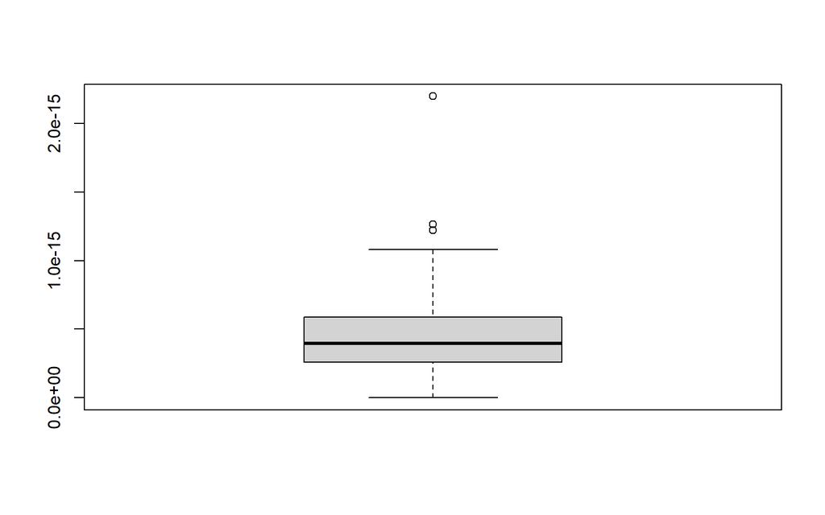

```r
boxplot(nnls_rmse)
```

```r
svr_residuals_100 <- svr_result_100 - propstable100
svr_rmse <- sqrt(rowMeans(svr_residuals_100^2))
svr_rmse <- data.frame(svr_rmse)

summary(svr_rmse)
```

```
##     svr_rmse
##  Min.   :8.306e-05
##  1st Qu.:1.388e-04
##  Median :1.605e-04
##  Mean   :1.693e-04
##  3rd Qu.:1.867e-04
##  Max.   :3.722e-04
```

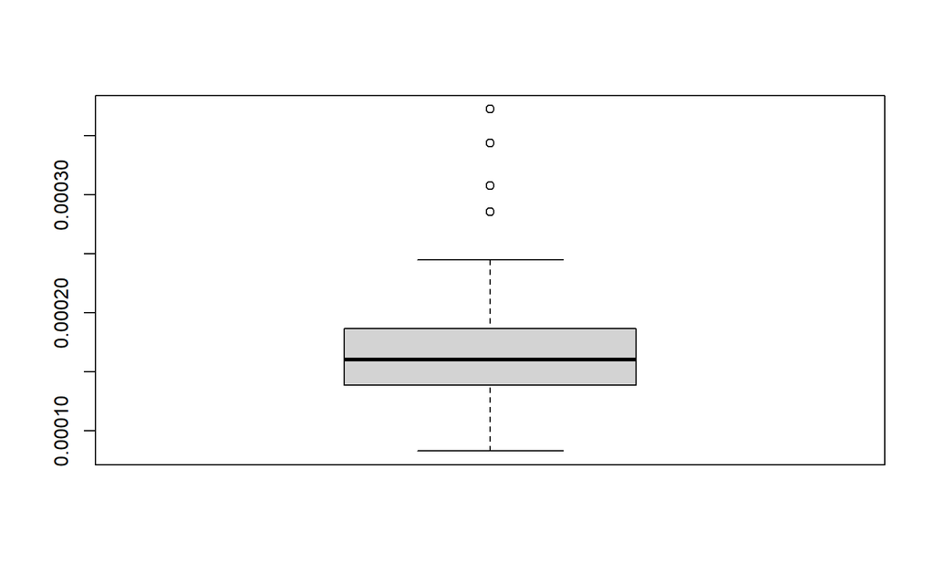

```r
boxplot(svr_rmse)
```

```r
qp_residuals_100 <- qp_result_100 - propstable100
qp_rmse <- sqrt(rowMeans(qp_residuals_100^2))
qp_rmse <- data.frame(qp_rmse)

summary(qp_rmse)
```

```
##     qp_rmse
##  Min.   :0.000e+00
##  1st Qu.:5.395e-14
##  Median :8.065e-14
##  Mean   :7.938e-14
##  3rd Qu.:1.084e-13
##  Max.   :1.626e-13
```

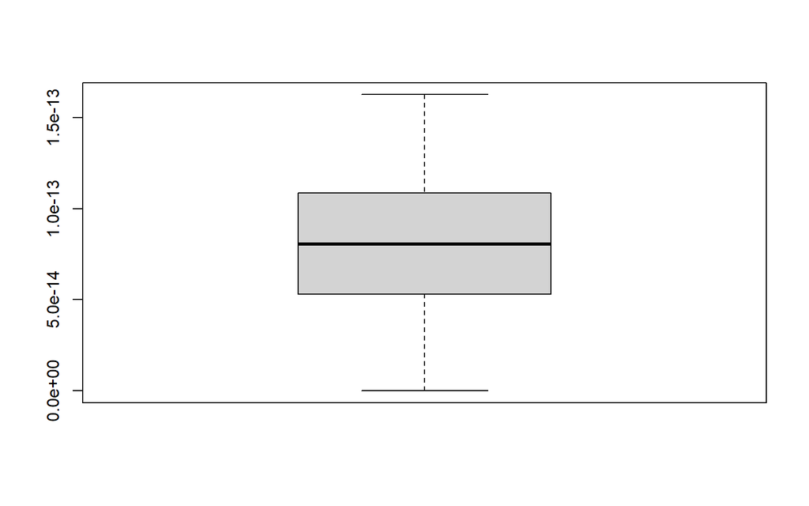

```r
boxplot(qp_rmse)
```

```r
rlm_residuals_100 <- rlm_result_100 - propstable100
rlm_rmse <- sqrt(rowMeans(rlm_residuals_100^2))
rlm_rmse <- data.frame(rlm_rmse)

summary(rlm_rmse)
```

```
##     rlm_rmse
##  Min.   :6.149e-19
##  1st Qu.:4.308e-16
##  Median :5.625e-16
##  Mean   :6.358e-16
##  3rd Qu.:7.926e-16
##  Max.   :1.904e-15
```

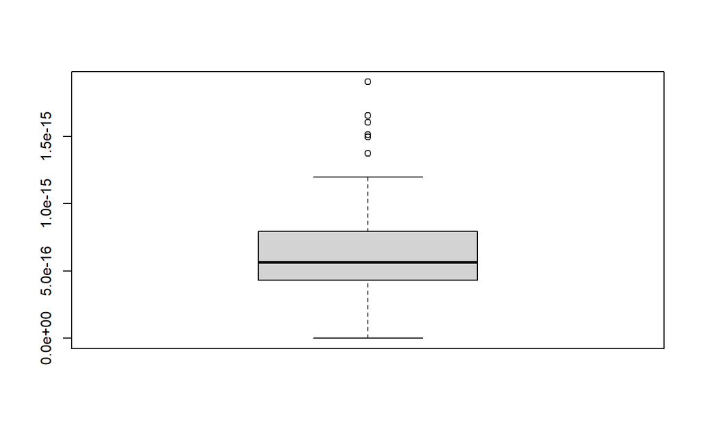

```r
boxplot(rlm_rmse)
```

**Time Complexity**

- Time Complexity

```r
nnls_time1 <- system.time(deconvolute(bulk=bulktable1, model = "nnls"))[3]
```

```
## [1] "DECONVOLUTION WITH NNLS"
## [1] "SUMMARY OF PARTIAL R-SQUARED VALUES FOR NNLS : "
##    Min. 1st Qu.  Median    Mean 3rd Qu.    Max.
##       1       1       1       1       1       1
```

```r
nnls_time10 <- system.time(deconvolute(bulk=bulktable10, model = "nnls"))[3]
```

```
## [1] "DECONVOLUTION WITH NNLS"
## [1] "SUMMARY OF PARTIAL R-SQUARED VALUES FOR NNLS : "
##    Min. 1st Qu.  Median    Mean 3rd Qu.    Max.
##       1       1       1       1       1       1
```

```r
nnls_time100 <- system.time(deconvolute(bulk=bulktable100, model = "nnls"))[3]
```

```
## [1] "DECONVOLUTION WITH NNLS"
## [1] "SUMMARY OF PARTIAL R-SQUARED VALUES FOR NNLS : "
##    Min. 1st Qu.  Median    Mean 3rd Qu.    Max.
##       1       1       1       1       1       1
```

```r
print(paste("Time To Deconvolute 1 Sample:", nnls_time1,"seconds (",nnls_time1/1,"seconds/sample )"))
```

```
## [1] "Time To Deconvolute 1 Sample: 3.56999999999999 seconds ( 3.56999999999999 seconds/sample )"
```

```r
print(paste("Time To Deconvolute 10 Samples:", nnls_time10,"seconds (",nnls_time10/10,"seconds/sample )"))
```

```
## [1] "Time To Deconvolute 10 Samples: 4.41000000000003 seconds ( 0.441000000000003 seconds/sample )"
```

```r
print(paste("Time To Deconvolute 100 Samples:", nnls_time100,"seconds (",nnls_time100/100,"seconds/sample )"))
```

```
## [1] "Time To Deconvolute 100 Samples: 9.45999999999998 seconds ( 0.0945999999999998 seconds/sample )"
```

```r
svr_time1 <- system.time(deconvolute(bulk=bulktable1, model = "svr"))[3]
```

```
## [1] "DECONVOLUTION WITH SVR"
## [1] "SUMMARY OF PARTIAL R-SQUARED VALUES FOR SVR : "
##    Min. 1st Qu.  Median    Mean 3rd Qu.    Max.
##       1       1       1       1       1       1
```

```r
svr_time10 <- system.time(deconvolute(bulk=bulktable10, model = "svr"))[3]
```

```
## [1] "DECONVOLUTION WITH SVR"
## [1] "SUMMARY OF PARTIAL R-SQUARED VALUES FOR SVR : "
##    Min. 1st Qu.  Median    Mean 3rd Qu.    Max.
##       1       1       1       1       1       1
```

```r
svr_time100 <- system.time(deconvolute(bulk=bulktable100, model = "svr"))[3]
```

```
## [1] "DECONVOLUTION WITH SVR"
## [1] "SUMMARY OF PARTIAL R-SQUARED VALUES FOR SVR : "
##    Min. 1st Qu.  Median    Mean 3rd Qu.    Max.
##  0.9999  1.0000  1.0000  1.0000  1.0000  1.0000
```

```r
print(paste("Time To Deconvolute 1 Sample:", svr_time1,"seconds (",svr_time1/1,"seconds/sample)"))
```

```
## [1] "Time To Deconvolute 1 Sample: 7.85000000000002 seconds ( 7.85000000000002 seconds/sample)"
```

```r
print(paste("Time To Deconvolute 10 Samples:", svr_time10,"seconds (",svr_time10/10,"seconds/sample)"))
```

```
## [1] "Time To Deconvolute 10 Samples: 33.6 seconds ( 3.36 seconds/sample)"
```

```r
print(paste("Time To Deconvolute 100 Samples:", svr_time100,"seconds (",svr_time100/100,"seconds/sample)"))
```

```
## [1] "Time To Deconvolute 100 Samples: 284.89 seconds ( 2.8489 seconds/sample)"
```

```r
qp_time1 <- system.time(deconvolute(bulk=bulktable1, model = "qp"))[3]
```

```
## [1] "DECONVOLUTION WITH QP"
## [1] "SUMMARY OF PARTIAL R-SQUARED VALUES FOR QP : "
##    Min. 1st Qu.  Median    Mean 3rd Qu.    Max.
##       1       1       1       1       1       1
```

```r
qp_time10 <- system.time(deconvolute(bulk=bulktable10, model = "qp"))[3]
```

```
## [1] "DECONVOLUTION WITH QP"
## [1] "SUMMARY OF PARTIAL R-SQUARED VALUES FOR QP : "
##    Min. 1st Qu.  Median    Mean 3rd Qu.    Max.
##       1       1       1       1       1       1
```

```r
qp_time100 <- system.time(deconvolute(bulk=bulktable100, model = "qp"))[3]
```

```
## [1] "DECONVOLUTION WITH QP"
## [1] "SUMMARY OF PARTIAL R-SQUARED VALUES FOR QP : "
##    Min. 1st Qu.  Median    Mean 3rd Qu.    Max.
##       1       1       1       1       1       1
```

```r
print(paste("Time To Deconvolute 1 Sample:", qp_time1,"seconds (",qp_time1/1,"seconds/sample)"))
```

```
## [1] "Time To Deconvolute 1 Sample: 3.71999999999991 seconds ( 3.71999999999991 seconds/sample)"
```

```r
print(paste("Time To Deconvolute 10 Samples:", qp_time10,"seconds (",qp_time10/10,"seconds/sample)"))
```

```
## [1] "Time To Deconvolute 10 Samples: 4.11000000000001 seconds ( 0.411000000000001 seconds/sample)"
```

```r
print(paste("Time To Deconvolute 100 Samples:", qp_time100,"seconds (",qp_time100/100,"seconds/sample)"))
```

```
## [1] "Time To Deconvolute 100 Samples: 9.11000000000001 seconds ( 0.0911000000000001 seconds/sample)"
```

```r
rlm_time1 <- system.time(deconvolute(bulk=bulktable1, model = "rlm"))[3]
```

```
## [1] "DECONVOLUTION WITH RLM"
## [1] "SUMMARY OF PARTIAL R-SQUARED VALUES FOR RLM : "
##    Min. 1st Qu.  Median    Mean 3rd Qu.    Max.
##       1       1       1       1       1       1
```

```r
rlm_time10 <- system.time(deconvolute(bulk=bulktable10, model = "rlm"))[3]
```

```
## [1] "DECONVOLUTION WITH RLM"
## [1] "SUMMARY OF PARTIAL R-SQUARED VALUES FOR RLM : "
##    Min. 1st Qu.  Median    Mean 3rd Qu.    Max.
##       1       1       1       1       1       1
```

```r
rlm_time100 <- system.time(deconvolute(bulk=bulktable100, model = "rlm"))[3]
```

```
## [1] "DECONVOLUTION WITH RLM"
## [1] "SUMMARY OF PARTIAL R-SQUARED VALUES FOR RLM : "
##    Min. 1st Qu.  Median    Mean 3rd Qu.    Max.
##       1       1       1       1       1       1
```

```r
print(paste("Time To Deconvolute 1 Sample:", rlm_time1,"seconds (",rlm_time1/1,"seconds/sample)"))
```

```
## [1] "Time To Deconvolute 1 Sample: 4.26999999999998 seconds ( 4.26999999999998 seconds/sample)"
```

```r
print(paste("Time To Deconvolute 10 Samples:", rlm_time10,"seconds (",rlm_time10/10,"seconds/sample)"))
```

```
## [1] "Time To Deconvolute 10 Samples: 9.25 seconds ( 0.925 seconds/sample)"
```

```r
print(paste("Time To Deconvolute 100 Samples:", rlm_time100,"seconds (",rlm_time100/100,"seconds/sample)"))
```

```
## [1] "Time To Deconvolute 100 Samples: 70.42 seconds ( 0.7042 seconds/sample)"
```

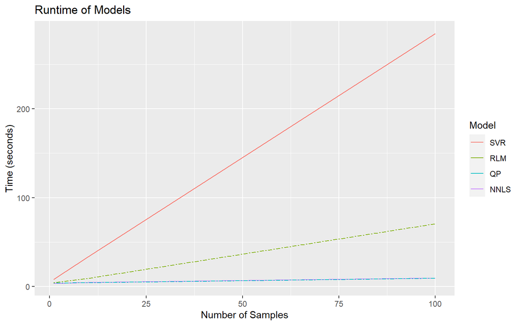

```r
time_data <- data.frame(c(1,10,100),
                        c(nnls_time1, nnls_time10, nnls_time100),
                        c(svr_time1, svr_time10, svr_time100),
                        c(qp_time1, qp_time10, qp_time100),
                        c(rlm_time1, rlm_time10, rlm_time100))
colnames(time_data) <- c("NumberOfSamples", "NNLS", "SVR", "QP", "RLM")

ggplot2::ggplot(time_data, ggplot2::aes(x=NumberOfSamples)) +
  ggplot2::geom_line(ggplot2::aes(y = NNLS, color = "steelblue")) +
  ggplot2::geom_line(ggplot2::aes(y = SVR, color="green")) +
  ggplot2::geom_line(ggplot2::aes(y = QP, color = "pink"),linetype="twodash") +
  ggplot2::geom_line(ggplot2::aes(y = RLM, color="orange"),linetype="twodash") +
  ylab("Time (seconds)")+  xlab("Number of Samples")+
  scale_color_discrete(name = "Model", labels = c("SVR", "RLM","QP", "NNLS"))+
  ggplot2::ggtitle("Runtime of Models")
```

**Interpreting the Results**

- Scatter Plots

Here we compare the actual and predicted cell proportions, colored by the cell type. There are three scatter plots per model, representing all samples, 5th percentile, and 95th percentile of RMSEs. This illustrates how each method performs in a best-case and worst-case scenario (95th percentile of RMSE values represent worst-case and 5th percentile represents best case).

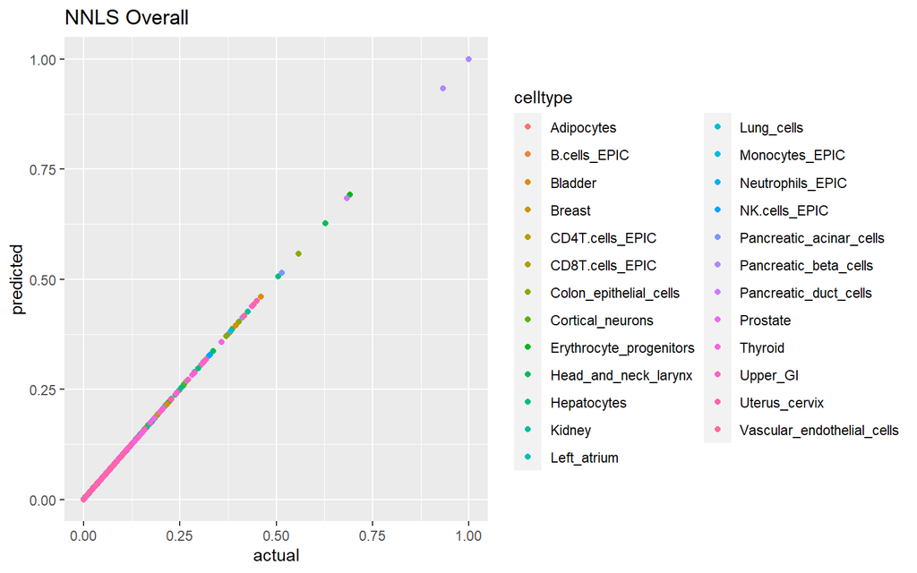

```r
samplenumslist <- c()
for (i in 1:100) {samplenumslist <- append(samplenumslist, paste("Sample",i))}
scatterdf_nnls <- data.frame(propstable100[,1],nnls_result_100[,1],
                             colnames(propstable100)[1])
colnames(scatterdf_nnls) <- c("actual", "predicted", "celltype")
for (i in 2:25) {
    scatterdf1 <- data.frame(propstable100[,i], nnls_result_100[,i],
                             colnames(propstable100)[i])
    colnames(scatterdf1) <- c("actual", "predicted", "celltype")
    scatterdf_nnls <- rbind(scatterdf_nnls, scatterdf1)
}
scatterdf_nnls[,4] <- samplenumslist
colnames(scatterdf_nnls)[4] <- "samplenum"
sp_nnls <- ggplot2::ggplot(scatterdf_nnls,
                           ggplot2::aes(x=actual, y=predicted,color=celltype)) +
  ggplot2::geom_point() +
  ggplot2::ggtitle("NNLS Overall")
sp_nnls
```

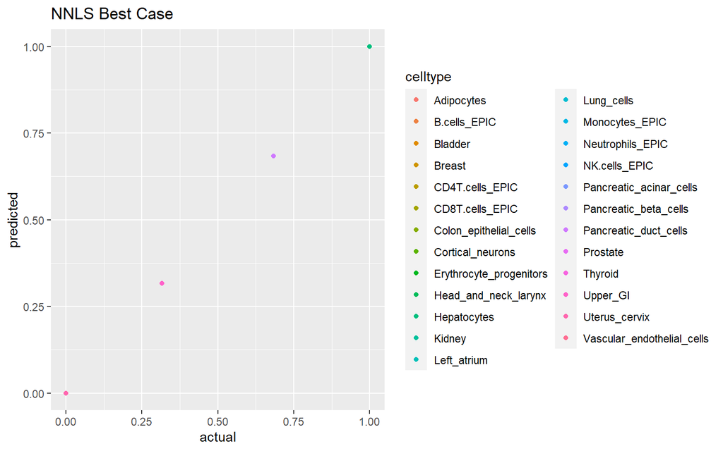

```r
nnls_bestcase <- subset(nnls_rmse,
                        nnls_rmse <= quantile(nnls_rmse,
                                              probs = c(0, 0.05, 0.95, 1))[2])
scatter_nnls_bestcase <- subset(scatterdf_nnls,
                                is.element(scatterdf_nnls[,4],
                                           rownames(nnls_bestcase)))
sp_nnls_bestcase <- ggplot2::ggplot(scatter_nnls_bestcase,
                                    ggplot2::aes(x=actual, y=predicted,
                                                 color=celltype)) + ggplot2::geom_point()+
  ggplot2::ggtitle("NNLS Best Case")
sp_nnls_bestcase
```

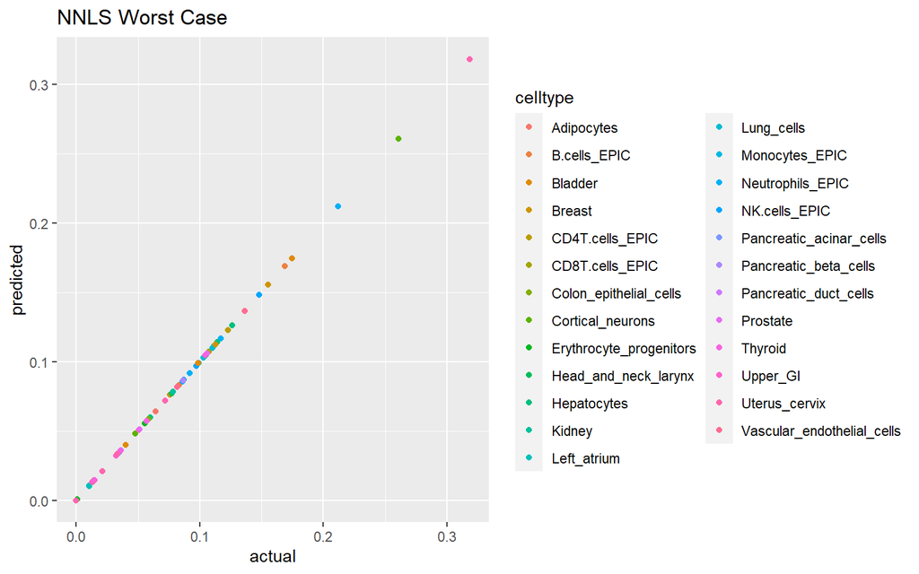

```r
nnls_worstcase <- subset(nnls_rmse,
                         nnls_rmse >= quantile(nnls_rmse,
                                               probs = c(0, 0.05, 0.95, 1))[3])
scatter_nnls_worstcase <- subset(scatterdf_nnls,
                                 is.element(scatterdf_nnls[,4],
                                            rownames(nnls_worstcase)))
sp_nnls_worstcase <- ggplot2::ggplot(scatter_nnls_worstcase,
                                     ggplot2::aes(x=actual, y=predicted,
                                                  color=celltype)) +
  ggplot2::geom_point()+
  ggplot2::ggtitle("NNLS Worst Case")
sp_nnls_worstcase
```

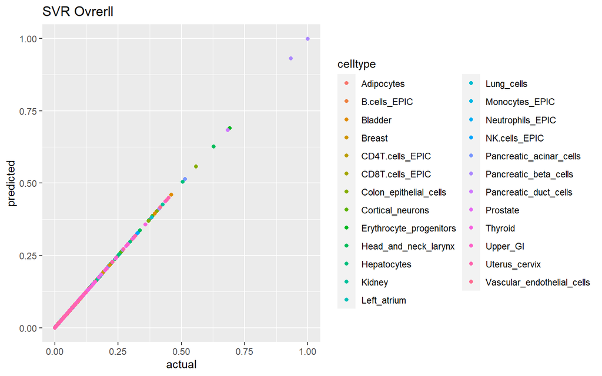

```r
scatterdf_svr <- data.frame(propstable100[,1], svr_result_100[,1],
                            colnames(propstable100)[1])
colnames(scatterdf_svr) <- c("actual", "predicted", "celltype")
for (i in 2:25) {
    scatterdf1 <- data.frame(propstable100[,i], svr_result_100[,i],
                             colnames(propstable100)[i])
    colnames(scatterdf1) <- c("actual", "predicted", "celltype")
    scatterdf_svr <- rbind(scatterdf_svr, scatterdf1)
}
scatterdf_svr[,4] <- samplenumslist
colnames(scatterdf_svr)[4] <- "samplenum"
sp_svr <- ggplot2::ggplot(scatterdf_svr,
                          ggplot2::aes(x=actual, y=predicted, color=celltype))+
  ggplot2::geom_point() +
  ggplot2::ggtitle("SVR Ovrerll")
sp_svr
```

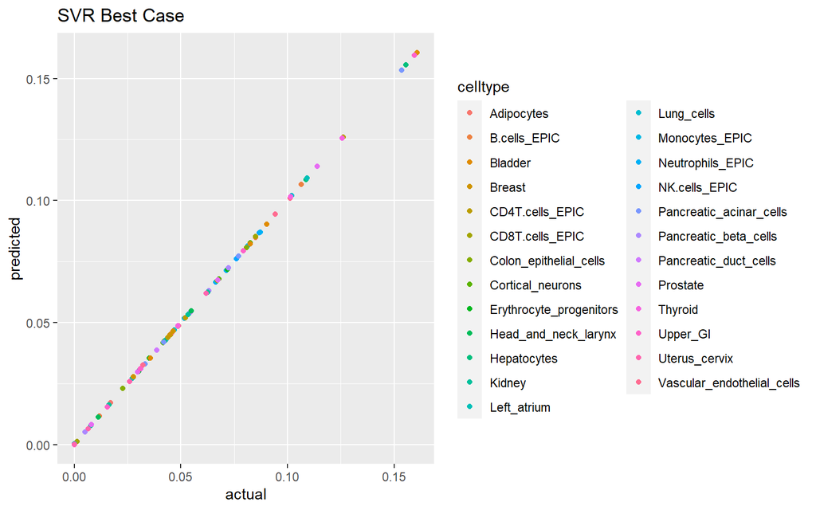

```r
svr_bestcase <- subset(svr_rmse,
                       svr_rmse <= quantile(svr_rmse,
                                            probs = c(0, 0.05, 0.95, 1))[2])
scatter_svr_bestcase <- subset(scatterdf_svr, is.element(scatterdf_svr[,4],
                                                         rownames(svr_bestcase)))
sp_svr_bestcase <- ggplot2::ggplot(scatter_svr_bestcase,
                                   ggplot2::aes(x=actual, y=predicted,
                                                color=celltype)) +
  ggplot2::geom_point()+
  ggplot2::ggtitle("SVR Best Case")
sp_svr_bestcase
```

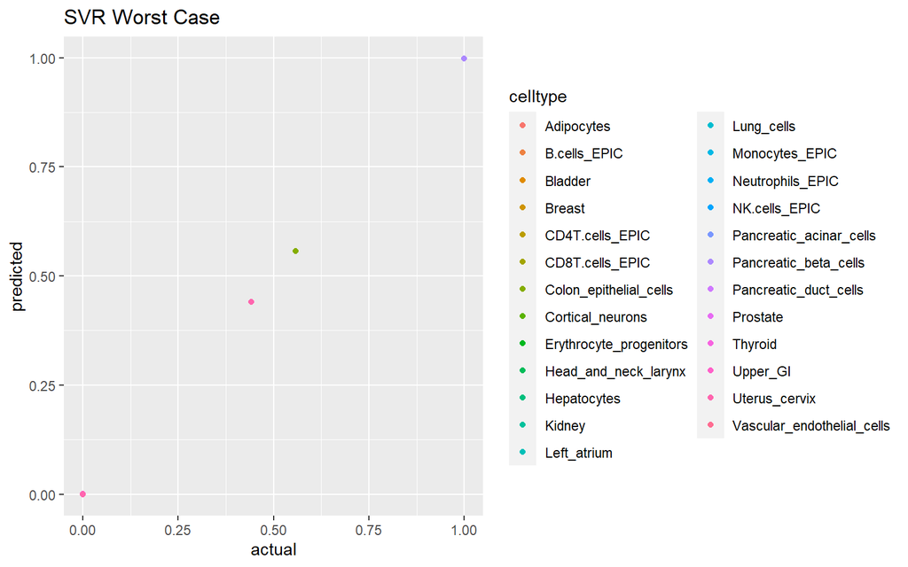

```r
svr_worstcase <- subset(svr_rmse,
                        svr_rmse >= quantile(svr_rmse,
                                             probs = c(0, 0.05, 0.95, 1))[3])
scatter_svr_worstcase <- subset(scatterdf_svr,
                                is.element(scatterdf_svr[,4],
                                           rownames(svr_worstcase)))
sp_svr_worstcase <- ggplot2::ggplot(scatter_svr_worstcase,
                                    ggplot2::aes(x=actual, y=predicted,
                                                 color=celltype)) +
  ggplot2::geom_point()+
  ggplot2::ggtitle("SVR Worst Case")
sp_svr_worstcase
```

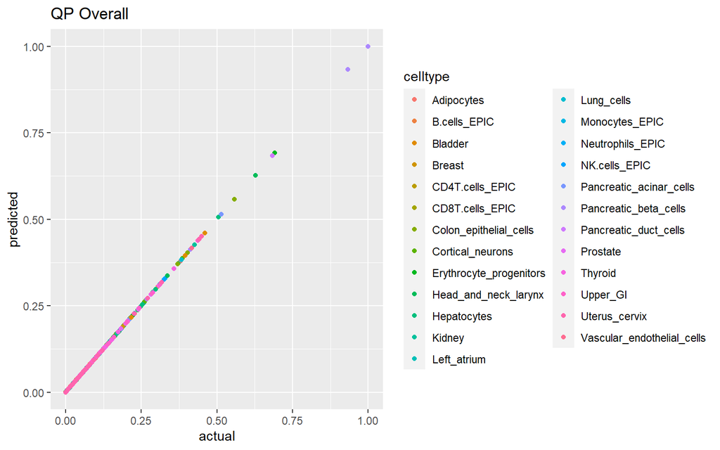

```r
scatterdf_qp <- data.frame(propstable100[,1], qp_result_100[,1],
                           colnames(propstable100)[1])
colnames(scatterdf_qp) <- c("actual", "predicted", "celltype")
for (i in 2:25) {
    scatterdf1 <- data.frame(propstable100[,i], qp_result_100[,i],
                             colnames(propstable100)[i])
    colnames(scatterdf1) <- c("actual", "predicted", "celltype")
    scatterdf_qp <- rbind(scatterdf_qp, scatterdf1)
}
scatterdf_qp[,4] <- samplenumslist
colnames(scatterdf_qp)[4] <- "samplenum"
sp_qp <- ggplot2::ggplot(scatterdf_qp,
                         ggplot2::aes(x=actual, y=predicted, color=celltype)) +
  ggplot2::geom_point() +
  ggplot2::ggtitle("QP Overall")
sp_qp
```

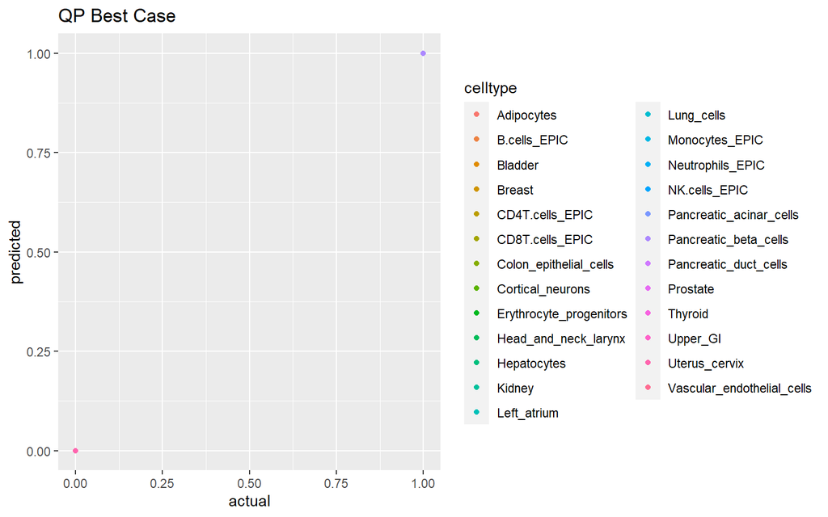

```r
qp_bestcase <- subset(qp_rmse,
                      qp_rmse <= quantile(qp_rmse,
                                          probs = c(0, 0.05, 0.95, 1))[2])
scatter_qp_bestcase <- subset(scatterdf_qp, is.element(scatterdf_qp[,4],
                                                       rownames(qp_bestcase)))
sp_qp_bestcase <- ggplot2::ggplot(scatter_qp_bestcase,
                                  ggplot2::aes(x=actual, y=predicted,
                                               color=celltype)) +
  ggplot2::geom_point()+
  ggplot2::ggtitle("QP Best Case")
sp_qp_bestcase
```

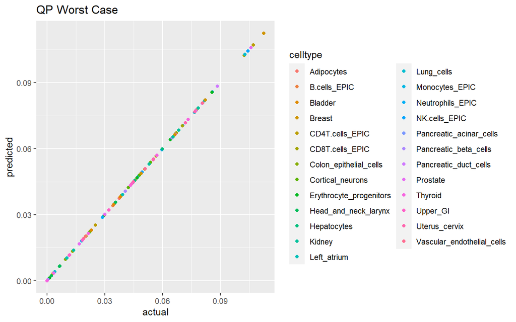

```r
qp_worstcase <- subset(qp_rmse,
                       qp_rmse >= quantile(qp_rmse,
                                           probs = c(0, 0.05, 0.95, 1))[3])
scatter_qp_worstcase <- subset(scatterdf_qp, is.element(scatterdf_qp[,4],
                                                        rownames(qp_worstcase)))
sp_qp_worstcase <- ggplot2::ggplot(scatter_qp_worstcase,
                                   ggplot2::aes(x=actual, y=predicted,
                                                color=celltype)) +
  ggplot2::geom_point()+
  ggplot2::ggtitle("QP Worst Case")
sp_qp_worstcase
```

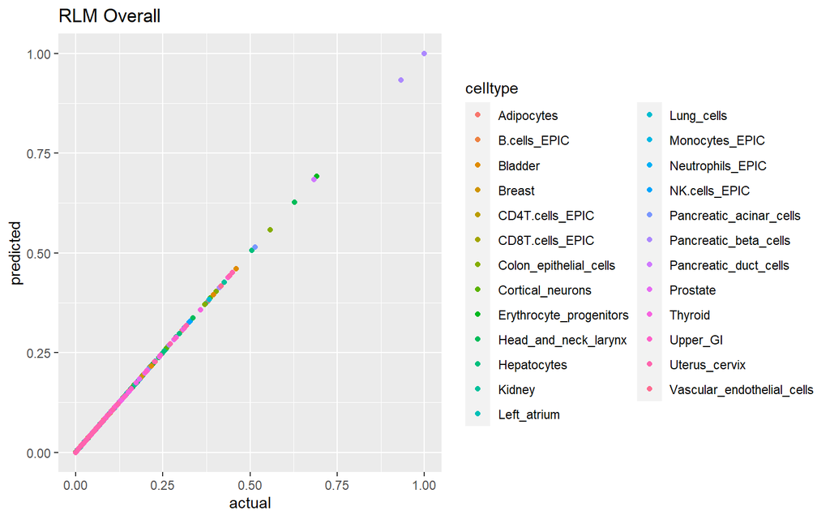

```r
scatterdf_rlm <- data.frame(propstable100[,1], rlm_result_100[,1],
                            colnames(propstable100)[1])
colnames(scatterdf_rlm) <- c("actual", "predicted", "celltype")
for (i in 2:25) {
    scatterdf1 <- data.frame(propstable100[,i], rlm_result_100[,i],
                             colnames(propstable100)[i])
    colnames(scatterdf1) <- c("actual", "predicted", "celltype")
    scatterdf_rlm <- rbind(scatterdf_rlm, scatterdf1)
}
scatterdf_rlm[,4] <- samplenumslist
colnames(scatterdf_rlm)[4] <- "samplenum"
sp_rlm <- ggplot2::ggplot(scatterdf_rlm,
                          ggplot2::aes(x=actual, y=predicted, color=celltype)) +
  ggplot2::geom_point() +
  ggplot2::ggtitle("RLM Overall")
sp_rlm
```

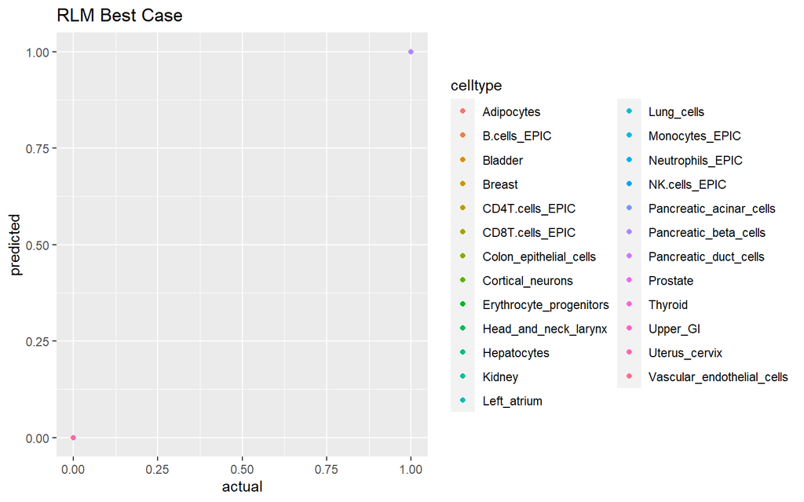

```r
rlm_bestcase <- subset(rlm_rmse,
                       rlm_rmse <= quantile(rlm_rmse,
                                            probs = c(0, 0.05, 0.95, 1))[2])
scatter_rlm_bestcase <- subset(scatterdf_rlm,
                               is.element(scatterdf_rlm[,4],
                                          rownames(rlm_bestcase)))
sp_rlm_bestcase <- ggplot2::ggplot(scatter_rlm_bestcase,
                                   ggplot2::aes(x=actual, y=predicted,
                                                color=celltype)) +
  ggplot2::geom_point()+ggplot2::ggtitle("RLM Best Case")
sp_rlm_bestcase
```

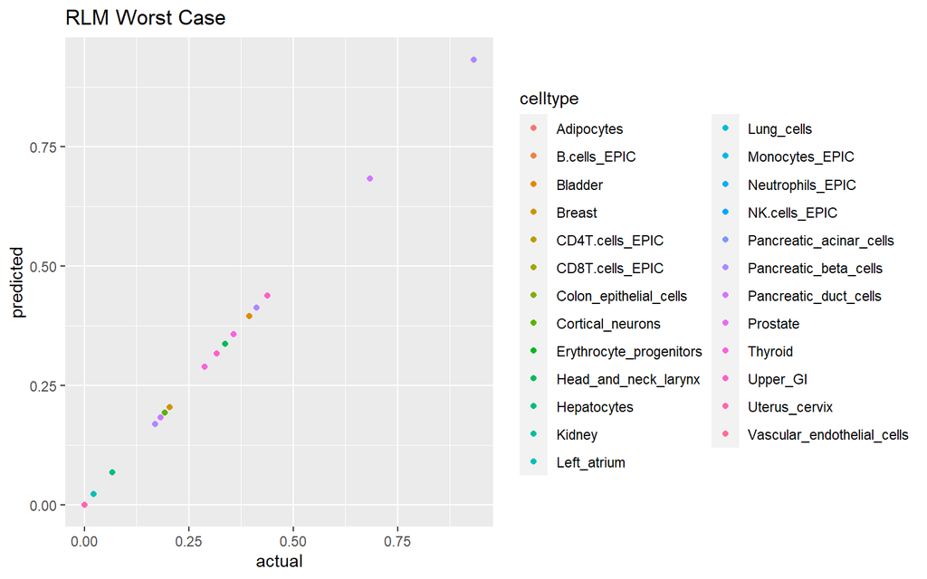

```r
rlm_worstcase <- subset(rlm_rmse,
                        rlm_rmse >= quantile(rlm_rmse,
                                             probs = c(0, 0.05, 0.95, 1))[3])
scatter_rlm_worstcase <- subset(scatterdf_rlm,
                                is.element(scatterdf_rlm[,4],
                                           rownames(rlm_worstcase)))
sp_rlm_worstcase <- ggplot2::ggplot(scatter_rlm_worstcase,
                                    ggplot2::aes(x=actual, y=predicted,
                                                 color=celltype)) +
  ggplot2::geom_point()+ggplot2::ggtitle("RLM Worst Case")
sp_rlm_worstcase
```

- Absolute Error by Cell Type

For each method (or in general), there may be cell types that are poorly predicted. This indicates improvements for the reference matrix are needed. Below,a set of boxplots illustrated for each method. Each boxplot represents a cell type, and each datapoint in the boxplot is the absolute value of the difference between original and predicted proportions for a cell type in each random mixture. The cell types that are poorly predicted when compared to other cell types can be seen, if there are any.

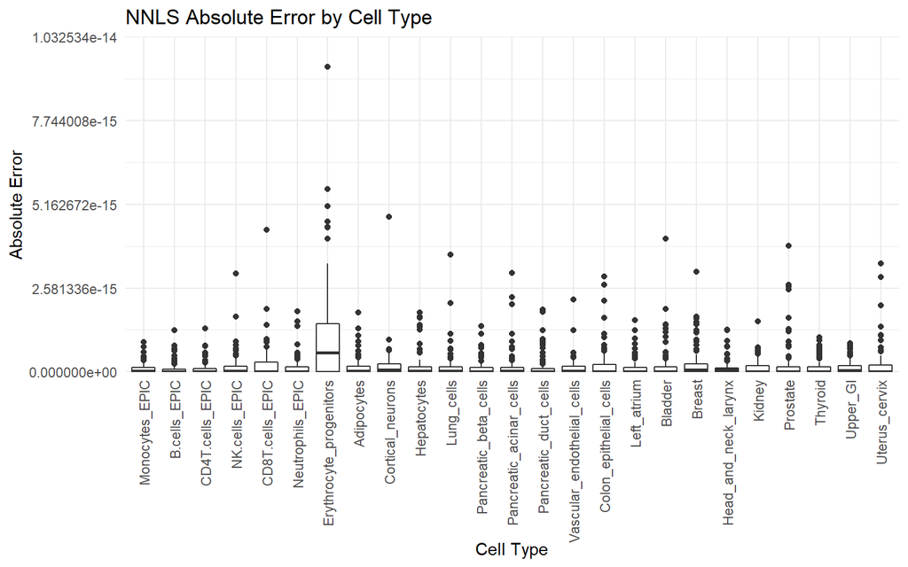

```r
nnls_absolute_residuals <- abs(nnls_residuals_100)
melt_nnls <- reshape2::melt(nnls_absolute_residuals)
plt_nnls <- ggplot2::ggplot(data = melt_nnls,
                            ggplot2::aes(x = variable, y = value))
plt_nnls + ggplot2::geom_boxplot() + ggplot2::theme_minimal() +
  ggplot2::labs(x = "Cell Type", y = "Absolute Error") +
  ggplot2::theme(axis.text.x = element_text(angle=90, hjust=1, vjust=0.5)) +
  ggplot2::scale_y_continuous(expand=expand_scale(mult=c(0,0.1))) +
  ggplot2::ggtitle("NNLS Absolute Error by Cell Type")
```

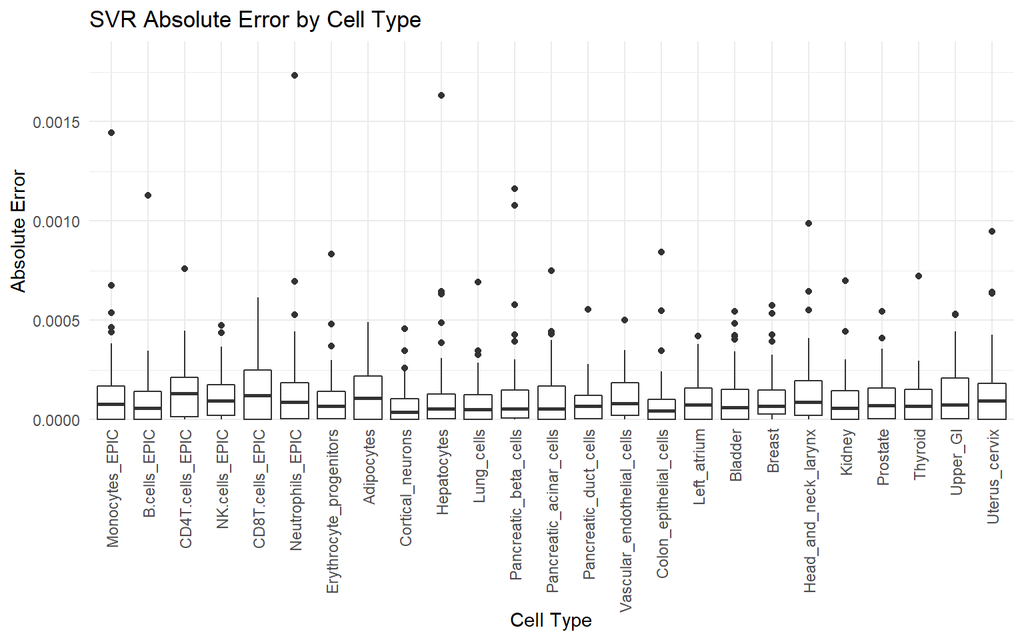

```r
svr_absolute_residuals <- abs(svr_residuals_100)
melt_svr <- reshape2::melt(svr_absolute_residuals)
plt_svr <- ggplot2::ggplot(data = melt_svr,
                           ggplot2::aes(x = variable,y = value))
plt_svr + ggplot2::geom_boxplot() + ggplot2::theme_minimal() +
  ggplot2::labs(x = "Cell Type", y = "Absolute Error") +
  ggplot2::theme(axis.text.x = element_text(angle=90, hjust=1, vjust=0.5)) +
  ggplot2::scale_y_continuous(expand=expand_scale(mult=c(0,0.1))) +
  ggplot2::ggtitle("SVR Absolute Error by Cell Type")
```

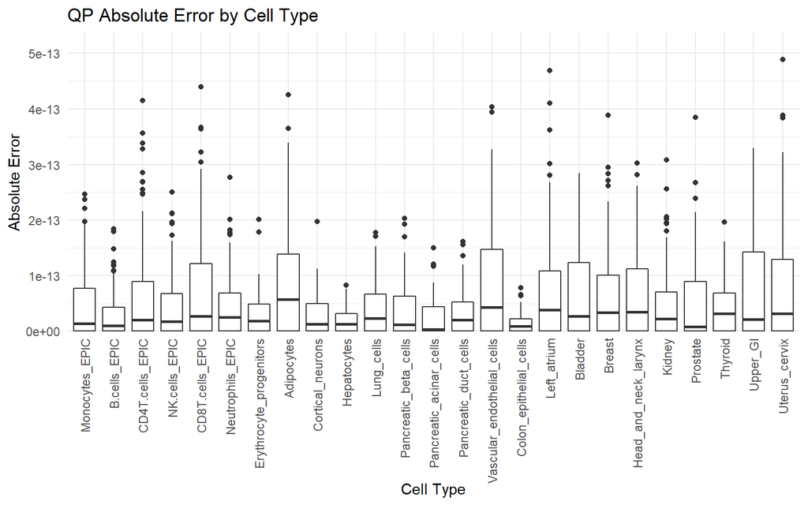

```r
qp_absolute_residuals <- abs(qp_residuals_100)
melt_qp <- reshape2::melt(qp_absolute_residuals)
plt_qp <- ggplot2::ggplot(data = melt_qp ,
                          ggplot2::aes(x = variable,y = value))
plt_qp + ggplot2::geom_boxplot() + ggplot2::theme_minimal() +
  ggplot2::labs(x = "Cell Type", y = "Absolute Error") +
  ggplot2::theme(axis.text.x = element_text(angle=90, hjust=1, vjust=0.5)) +
  ggplot2::scale_y_continuous(expand=expand_scale(mult=c(0,0.1))) +
  ggplot2::ggtitle("QP Absolute Error by Cell Type")
```

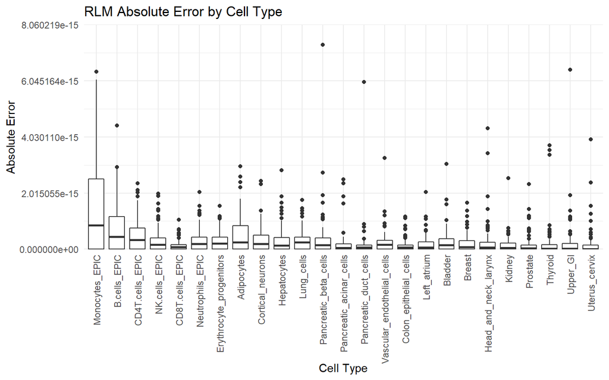

```r
rlm_absolute_residuals <- abs(rlm_residuals_100)
melt_rlm <- reshape2::melt(rlm_absolute_residuals)
plt_rlm <- ggplot2::ggplot(data = melt_rlm ,
                           ggplot2::aes(x = variable, y = value))
plt_rlm + ggplot2::geom_boxplot() + ggplot2::theme_minimal() +
  ggplot2::labs(x = "Cell Type", y = "Absolute Error") +
  ggplot2::theme(axis.text.x = element_text(angle=90, hjust=1, vjust=0.5)) +
  ggplot2::scale_y_continuous(expand=expand_scale(mult=c(0,0.1))) +
  ggplot2::ggtitle("RLM Absolute Error by Cell Type")
```

```r
stopCluster(cl)
```